# Leaf lifespan allometry

Sylvain Schmitt sylvain.schmitt@agroparistech.fr

2017-05-11

# Introduction

TROLL model currently encompass Reich’s 1991 and 1997 and Wright’s 2004 allometries to estimate leaf lifespan with (Reich *et al.* 1991, 1997; Wright *et al.* 2004). But we have shown that Reich’s allometries are underestimating leaf lifespan for low LMA species. Moreover simulations estimated unrealistically low aboveground biomass for low LMA species. We assumed Reich’s allometries underestimation of leaf lifespan for low LMA species being the source of unrealistically low aboveground biomass inside TROLL simulations. We decided to find a better allometry with Wright *et al.* (2004) GLOPNET dataset.

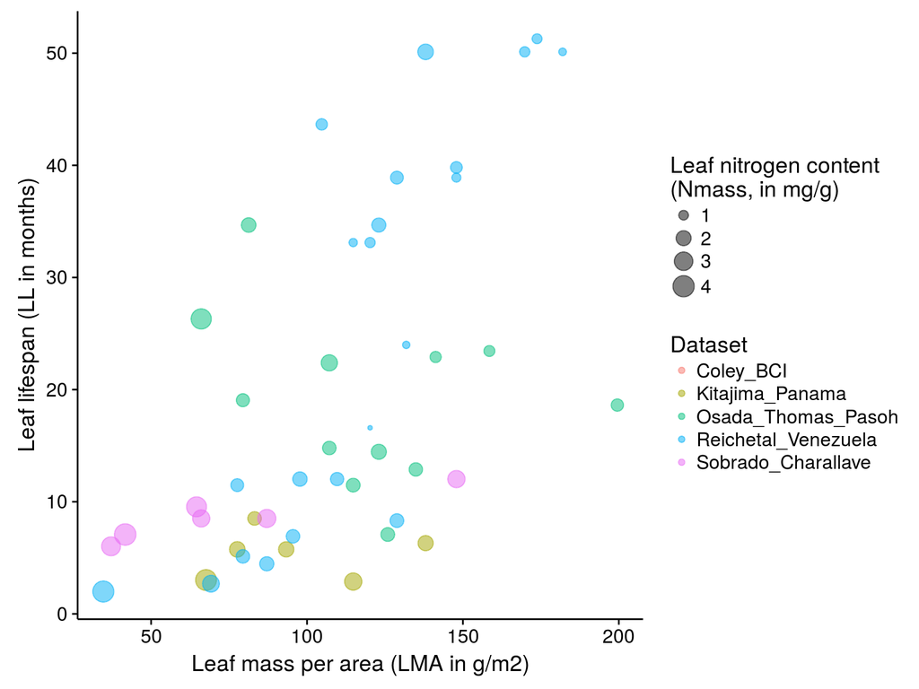

Figure 1: Leaf mass per area (LMA), leaf nitrogen content (Nmass) and leaflifespan (LL). *Leaf mass per area (LMA in $g.m^{-2}$), leaf nitrogen content (Nmass, in $mg.g^-1$) and leaf lifespan (LL in $months$) are taken in GLOPNET dataset from Wright *et al.* (2004).*

# First model

We tested different models and we kept the model with the best tradeoff between model complexity, convergence, likelihood, and prediction quality (see leaf lifespan model document). We found following model, named **M1**:
$$M1~~ {LL_s}_j \sim \mathcal{logN}(\beta_0*e^{{\beta_1}_s*{LMA_s}_j - {\beta_2}_s*{Nmass_s}_j},\,\sigma)\,$$
$$s=1,...,S_{=4}~, ~~j=1,...,n_s$$
$${\beta_i}_s \sim \mathcal{N}({\beta_i},\,\sigma_i)\,^I, ~~(\beta_i, \sigma, \sigma_i) \sim \mathcal{\Gamma}(0.001,\,0.001)\,^{2I+1}$$

# Second model

## Data gathering

We gathered data from TRY database to evaluate and improve previous model. We requested functional traits available in Bridge dataset and leaf lifespan for tropical species present in GLOPNET dataset and used in TROLL (see table 1). We currently obtained public data, which are used in subsequent analysis. **We are waiting for restricted data to get an extended dataset and repeat the analysis.**

Table 1: Functional traits gathered with TRY.

| Name | Trait | Unit | TRYcode |
| --- | --- | --- | --- |
| LL | Leaf lifespan (longevity) | month | 12 |
| SLA | Leaf area per leaf dry mass (specific leaf area, SLA) | $m^2.kg^{-1}$ | 11 |
| N | Leaf nitrogen (N) content per leaf dry mass | $mg.g^{-1}$ | 15 |
| P | Leaf phosphorus (P) content per leaf dry mass | $mg.g^{-1}$ | 14 |
| wsg | Stem dry mass per stem fresh volume (stem specific density) | $mg.mm^{-3}$ | 4 |

## Model

We compiled GLOPNET, TRY, and DRYAD databases to gather the biggest dataset. We kept dataset given by GLOPNET as origin dataset for observations. It correspond to leaf lifespan and also to LMA and Nmass in most of cases. We measured variable importance in functionnal traits to explain leaf lifespan with out-of bag method applied on a random forest (see Table 2).

Table 2: Variable importance calculated with out-of the bag method applied on a random forest. *Leaf lifespan (LL in $months$) is taken in GLOPNET database from Wright *et al.* (2004). Leaf mass per area (LMA in $g.m^{-2}$), and leaf nitrogen content (Nmass, in $mg.g^-1$) are taken both in TRY (https://www.try-db.org) and GLOPNET databases. Wood specific gravity (wsg in ) is taken both in TRY and DRYAD databases.*

|  | %IncMSE | IncNodePurity |
| --- | --- | --- |
| LMA | 103.39502 | 2183.717 |
| Nm | 152.17317 | 2453.402 |
| wsg | 52.80271 | 1475.523 |

We decided to add to model **M1**, wood specific gravity as a new predictor through a parameter $\beta_3$ in a new model named **M10**. We removed dataset random effect on $\beta_3$ due to the fact that all wood specific gravities were provided by DRYAD database. Due to a correlation between $\beta_0$ and $\beta_3$ in **M10** (see figure 5), we tried also a model **M11** without intercept $\beta_0$. We then sampled all models with this composite dataset, and obtained following results :

| M | Model | ML |
| --- | --- | --- |
| M1 | ${LL_s}_j \sim \mathcal{logN}(\beta_0 + {\beta_1}_s*{LMA_s}_j - {\beta_2}_s*{Nmass_s}_j,\,\sigma)\,$ | 9.921572 |
| M10 | ${LL_s}_j \sim \mathcal{logN}(\beta_0 + {\beta_1}_s*{LMA_s}_j - {\beta_2}_s*{Nmass_s}_j + {\beta_3}*{wsg}_j,\,\sigma)\,$ | 15.127427 |
| M11 | ${LL_s}_j \sim \mathcal{logN}({\beta_1}_s*{LMA_s}_j - {\beta_2}_s*{Nmass_s}_j + {\beta_3}*{wsg}_j,\,\sigma)\,$ | 13.598262 |

### Posterior distributions and convergence

All model have correctly converged.

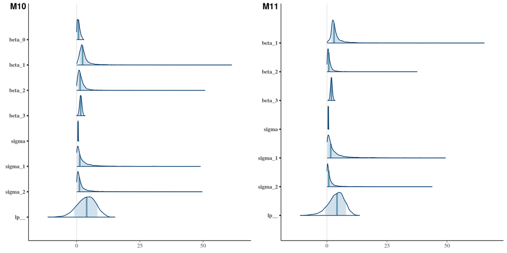

Figure 3: Parameters posterior ditribution. *Light blue area represents 80% confidence interval, and vertical blue line the mean.*

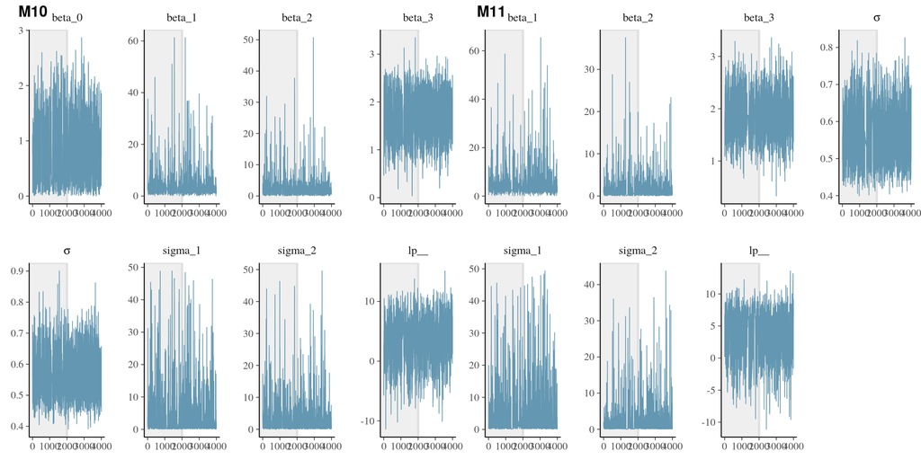

Figure 4: Parameters markov chains. *Light grey area represents warmup iterations.*

### Parameters correlation

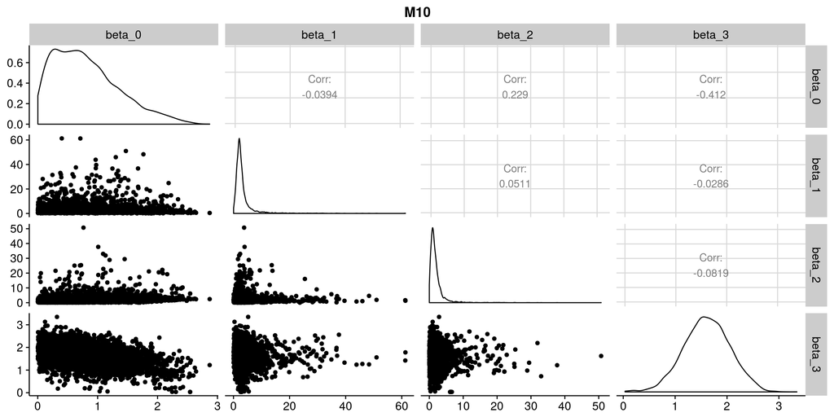

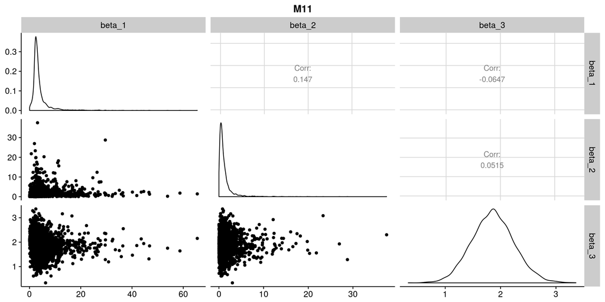

Figure 5: Parameters pairs plot for model **M10** and **M11**. *Parameters density distribution, pairs plot and Pearson’s coefficient of correlation.*

### Model predictions

We can denote that retained vector of parameters with maximum likelihood for model **M11** is close to 95% confidence limit.

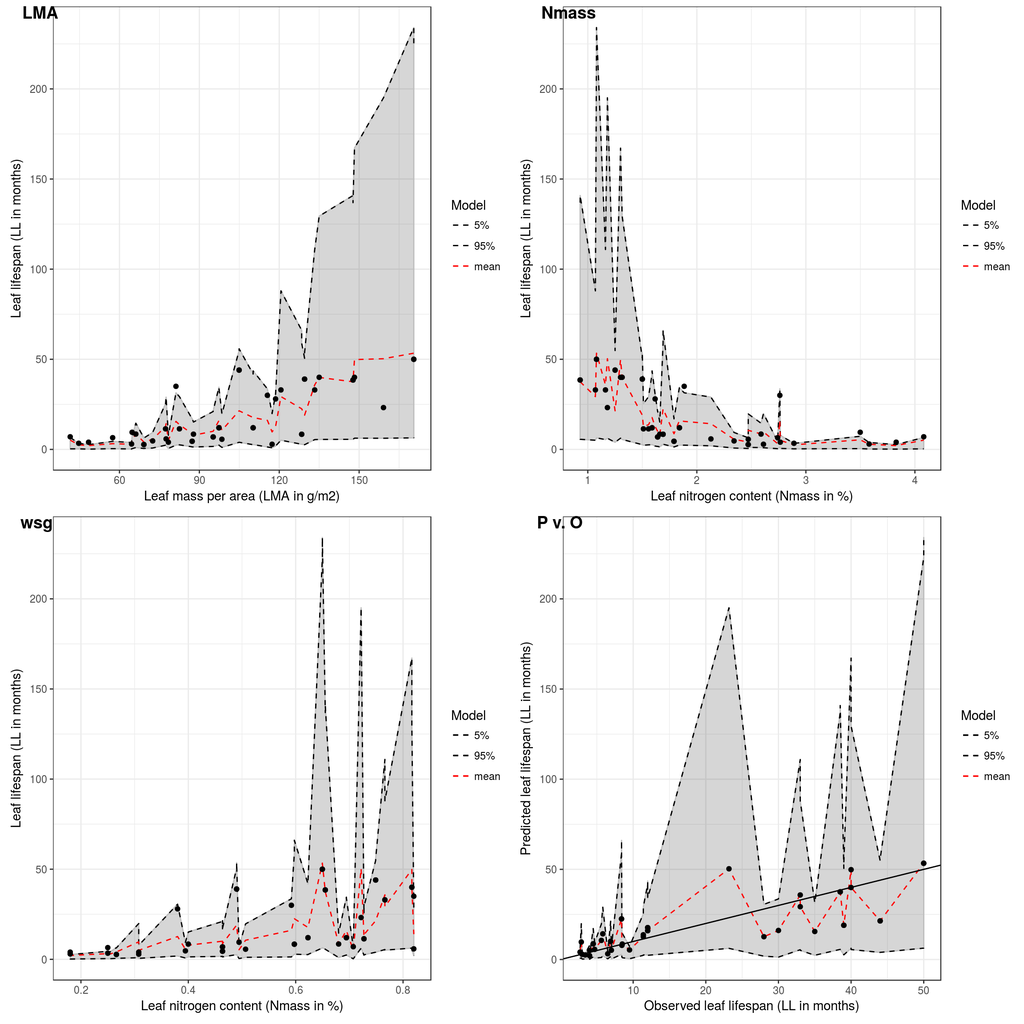

$$M11:~~ LL = e^{0.017*LMA-0.103*Nmass + 1.94*wsg}$$

# TROLL tests

We finally tested the new allometry obtained with **M11** on TROLL data (figure 7) and with TROLL simulations (figure 8).

## TROLL predictions

Minimum leaf lifespan is now above 3 months for model **M11** with TROLL species dataset. Moreover lowest leaf lifespan species are not the one with the smallest LMA with new model. Lastly, model **M11** variation of leaf lifespan is almost spanning all previous allometries prediciton on LMA axis.

[interactive chart not shown]

Figure 7: Leaflifespan predictions for model different allometries with leaf mass per area (LMA), and leaf nitrogen content (Nmass), and wood specific gravity (wsg). *Leaf lifespan (LL in $months$) is predicted with model M1, M10, and M11 fits or Reich’s and Wright’s allometries (Reich *et al.* 1991). Leaf mass per area (LMA in $g.m^{-2}$) leaf nitrogen content (Nmass, in %) , and wood specific gravity (wsg in $mg.mm^{-3}$) are taken in BRIDGE dataset used by TROLL (Maréchaux & Chave).*

## TROLL simulation

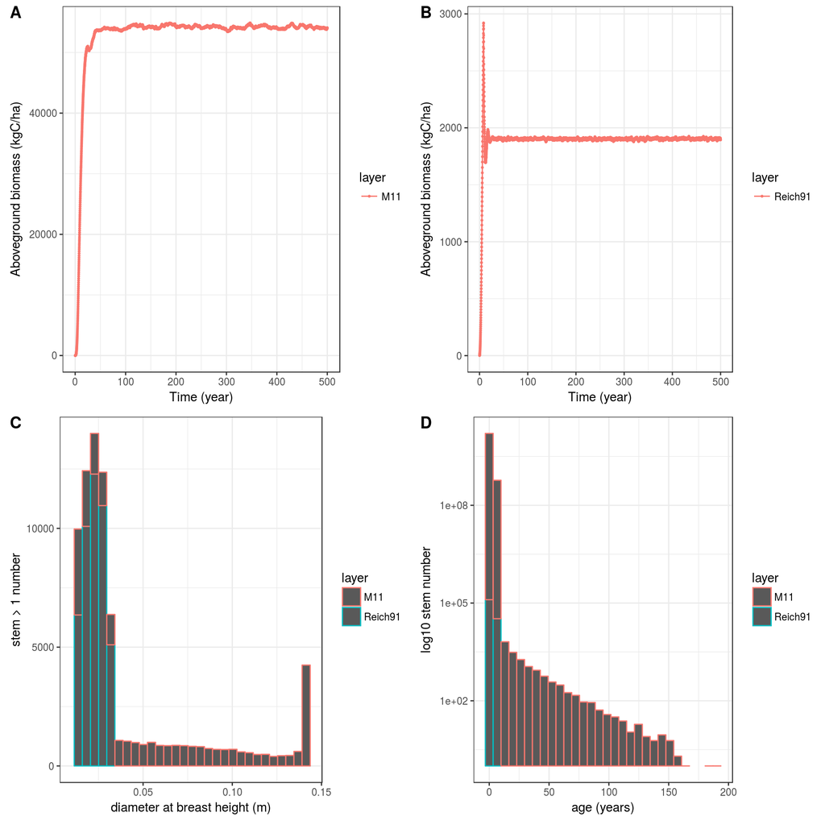

# References

Maréchaux, I. & Chave, J. Joint simulation of carbon and tree diversity in an Amazonian forest with an individual-based forest model. *Inprep*, 1–13.

Reich, P.B., Uhl, C., Walters, M.B. & Ellsworth, D.S. (1991). Leaf lifespan as a determinant of leaf structure and function among 23 amazonian tree species. *Oecologia*, **86**, 16–24.

Reich, P.B., Walters, M.B. & Ellsworth, D.S. (1997). From tropics to tundra: Global convergence in plant functioning. *Ecology*, **94**, 13730–13734.

Wright, I.J., Reich, P.B., Westoby, M., Ackerly, D.D., Baruch, Z., Bongers, F., Cavender-Bares, J., Chapin, T., Cornelissen, J.H.C., Diemer, M. & Others. (2004). The worldwide leaf economics spectrum. *Nature*, **428**, 821–827.